# Dialectos-Tidyverse

Escuela de Invierno en Métodos 2023, UCU

Martín Opertti

## Dialectos

En R podemos realizar una misma operación de muchas maneras distintas, en función de los paquetes o conjuntos de paquetes que utilizamos. Puesto de otra manera, R como lenguaje de programación tiene distintos “dialectos”, esto es, paquetes (o conjuntos de paquetes) con sus propias funciones, sintaxis y comunidad de usuarios.

Para la mayoría de las funciones requeridas para un análisis de datos estándar (importar datos, manipular, modelar y visualizar) existen -de forma muy simplificada- tres grandes dialectos: [R Base](https://stat.ethz.ch/R-manual/R-devel/library/base/html/00Index.html), [tidyverse](https://www.tidyverse.org/) y [data.table](https://rdatatable.gitlab.io/data.table/).

Comencemos por examinar el dataframe en cuestión (que ya importé y asigné con el nombre data):

```r
print(data)
```

```
## # A tibble: 35 × 5
##     year      gdp_lcu inflation unemployment presidente
##    <dbl>        <dbl>     <dbl>        <dbl> <chr>
##  1  1985 249277574100      72.2        NA    Sanguinetti
##  2  1986 271238450500      76.4        NA    Sanguinetti
##  3  1987 292918912000      63.6        NA    Sanguinetti
##  4  1988 297256857900      62.2        NA    Sanguinetti
##  5  1989 300538279400      80.4        NA    Sanguinetti
##  6  1990 301431925100     113.         NA    Lacalle
##  7  1991 312099023700     102.          9.01 Lacalle
##  8  1992 336853433700      68.5         8.98 Lacalle
##  9  1993 345805469000      54.1         8.94 Lacalle
## 10  1994 370984750100      44.7         9    Lacalle
## # … with 25 more rows
```

Ahora vamos a ver cómo podemos construir la tabla que queremos utilizando 3 fragmentos de código muy distintos. Cada uno de ellos se corresponde con uno de los “dialectos” que podemos utilizar en R.

### R Base

Primero veamos cómo podemos resumir estos datos para crear la tabla que queremos utilizando **R base**, es decir, las funciones que trae R por defecto. Las ventajas de esto es que no es necesario instalar ni cargar paquetes adicionales, y que es muy estable (las funciones no suelen cambiar). Sin embargo, puede resultar más complejo y difícil de interpetar que otras opciones.

```r
as.data.frame(t(sapply(X = split(
  x = data[which(data$presidente %in% c("Vázquez", "Sanguinetti")),
           which(colnames(data) %in% c("gdp_lcu", "inflation"))],
  f = data$presidente[which(data$presidente %in% c("Vázquez", "Sanguinetti"))],
  drop = TRUE),
  FUN = function(x) {apply(x, 2, mean)})))
```

```
##                  gdp_lcu inflation
## Sanguinetti 344923753631 46.168819
## Vázquez     584455715198  7.416316
```

### Datatable

Otra opción es usar las funciones de paquete data.table. Esta opción es un poco más sencilla aunque todavía es bastante difícil de leer sin conocer el código

```r
data_dt <- data
setDT(data_dt)
data_dt[presidente %in% c("Vázquez", "Sanguinetti"),
       c("presidente", "gdp_lcu", "inflation")  ][
         , lapply(.SD, mean), by = presidente]
```

```
##     presidente      gdp_lcu inflation
## 1: Sanguinetti 344923753631 46.168819
## 2:     Vázquez 584455715198  7.416316
```

### Tidyverse

La tercera opción es utilizar la sintáxis del Tidyverse. El código debajo realiza lo mismo que los dos anteriores pero en formato Tidyverse. Este formato está caracterizado por ser fácil de leer aún sin saber las funciones y por tener una gran comunidad de usuarios. Decimos que es fácil de leer debido a que está estructurado en distintos pasos que siguen un orden y que los nombres de las funciones se corresponden con verbos que describen los que hacen.

```r
data %>%
  filter(presidente %in% c("Vázquez", "Sanguinetti")) %>%
  select(presidente, gdp_lcu, inflation) %>%
  group_by(presidente) %>%
  summarise_all(mean)
```

```
## # A tibble: 2 × 3
##   presidente        gdp_lcu inflation
##   <chr>               <dbl>     <dbl>
## 1 Sanguinetti 344923753631.     46.2
## 2 Vázquez     584455715198.      7.42
```

Tomemos como ejemplo el fragmento de código anterior y analizemoslo. El código empieza con un objeto (`data`) y luego se le aplica la función `filter()` -que como su nombre indica filtra casos- para quedarnos con los años en los que presidió Vázquez o Sanguinetti. Luego aplicamos la función `select()` para quedarnos solamente con 3 variables, `presidente`, `gdp_lcu` e `inflation` que son las que necesitamos para crear nuestra tabla. Nuevamente el nombre de la función (`select()`) nos da un fuerte indicio de qué es lo que se está haciendo en esa línea de código. Por último, se aparecen las funciones `group_by()` para agrupar según la variable `presidente`, y la función `summarise_all()` para resumir los datos calculando la media.

Durante el curso, aprenderemos la mayoría de las cosas usando el Tidyverse.

## Más sobre el Tidyverse

[figure not shown]

[Tidyverse](https://www.tidyverse.org/) es una colección de paquetes diseñados para el análisis de datos. Este conjunto de paquetes comparte una filosofía de diseño, grámatica y estructura de datos. Las ventajas de Tidyverse están en su gramática (fácil de leer lo que invita a compartir y replicar), consistencia, alcance y su numerosa y creciente comunidad.

Tidyverse cuenta con varios paquetes que sirven para distintos tipos de tareas específicas. Podemos cargar todos los paquetes de forma conjunta:

```r
 # install.packages("tidyverse")
library(tidyverse)
```

O también podemos instalar/cargar los paquetes dentro del Tidyverse -como dplyr- de forma separada

```r
 # install.packages("dplyr")
library(dplyr)
```

La mejor manera de entender los principios de tidyverse es a través del libro del creador de tidyverse (Hadley Wickham) y Garrett Grolemund “R for Data Science” (2018). En este [enlace](https://es.r4ds.hadley.nz/) podrás encontrar su versión en español.

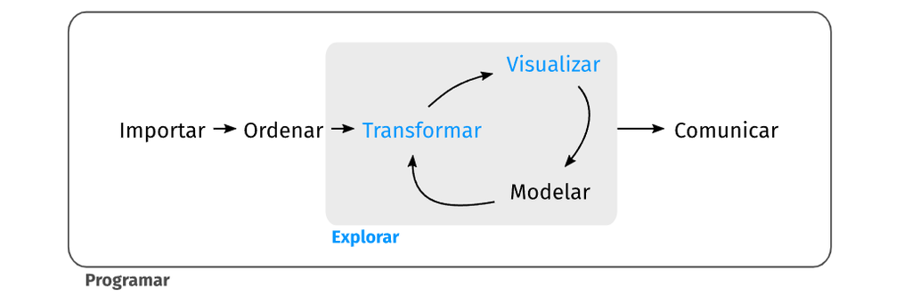

La lista debajo incluye los paquetes que componen el Tidyverse (son cargados o instalados por defecto cuando cargamos o instalamos el Tidyverse) y su fin.

[figure not shown]

- [readr](https://readr.tidyverse.org/): importar y exportar datos
- [dplyr](https://dplyr.tidyverse.org/): manipulación de datos
- [tidyr](https://tidyr.tidyverse.org/): manipulación de datos
- [ggplot2](https://ggplot2.tidyverse.org/): visualización de datos
- [purr](https://purrr.tidyverse.org/): programación avanzada
- [tibble](https://tibble.tidyverse.org/): estructura de datos
- [forcats](https://forcats.tidyverse.org/): factores
- [stringr](https://stringr.tidyverse.org/): variables de caracteres

Estos son algunos paquetes (para tareas más específicas) que forman parte del Tidyverse pero se tienen que cargar por separado:

- [readxl](https://readxl.tidyverse.org/): importar datos (excel)
- [haven](https://haven.tidyverse.org/): importar (Stata, SPSS, SAS)
- [lubridate](https://lubridate.tidyverse.org/): manipulación de fechas
- [rvest](https://rvest.tidyverse.org/): webscrapping
- [glue](https://www.tidyverse.org/blog/2017/10/glue-1.2.0/): combinar data
- [tidymodels](https://www.tidymodels.org/): modelar datos

[figure not shown]

Escuela de Invierno en Métodos, 2023. Universidad Católica del Uruguay